# 1 Crash Course Review Exercises

# MyUH: 1867424

# DATA SCIENCE 2, Dr. RIZK

#### **Import numpy,pandas,matplotlib,and sklearn. Also set visualizations to be shown inline in the notebook.**

```python
import pandas as pd
import seaborn as sns
import matplotlib.pyplot as plt
import numpy as np
%matplotlib inline
```

#### **Set Numpy’s Random Seed to 101**

```python
np.random.seed(101)
np.random.randint(10, size=5)
```

```
array([1, 6, 7, 9, 8])
```

```python
OldDataset=np.random.randint(100,size=(100,5))
OldDataset
```

```
array([[ 4, 63, 40, 60, 92],
       [64,  5, 12, 93, 40],
       [49, 83,  8, 29, 59],
       [34, 44, 72, 19, 10],
       [76, 95, 87,  0, 73],
       [ 8, 62, 36, 83, 99],
       [28, 63,  7, 10, 52],
       [56, 38, 73, 52, 18],
       [71, 15, 44,  0, 12],
       [17, 75, 79, 97, 93],
       [24, 36, 63, 19, 35],
       [30, 10, 60, 20, 27],
       [ 8, 86, 26, 87, 46],
       [47, 54, 86,  9, 45],
       [ 2, 18, 58, 92, 11],
```

[output cut: 85 more lines]

#### **Create a 2-D visualization using plt.imshow of the numpy matrix with a colorbar. Add a title to your plot. Bonus: Figure out how to change the aspect of the imshow() plot.**

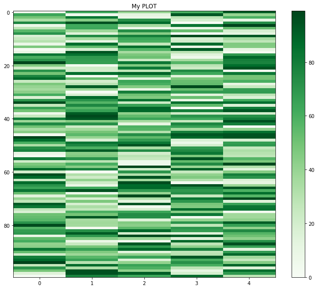

```python
plt.figure(figsize=(12,10))
plt.title('My PLOT')
color_map = plt.imshow(OldDataset,interpolation='nearest', aspect='auto')
color_map.set_cmap("Greens")
plt.colorbar()
plt.savefig("out.png")
```

#### **Now use pd.DataFrame() to read in this numpy array as a dataframe. Simple pass in the numpy array into that function to get back a dataframe. Pandas will auto label the columns to 0-4**

```python
NewDataset= pd.DataFrame(OldDataset)
NewDataset
```

|  | 0 | 1 | 2 | 3 | 4 |
| --- | --- | --- | --- | --- | --- |
| 0 | 4 | 63 | 40 | 60 | 92 |
| 1 | 64 | 5 | 12 | 93 | 40 |
| 2 | 49 | 83 | 8 | 29 | 59 |
| 3 | 34 | 44 | 72 | 19 | 10 |
| 4 | 76 | 95 | 87 | 0 | 73 |
| ... | ... | ... | ... | ... | ... |
| 95 | 26 | 87 | 65 | 60 | 89 |
| 96 | 70 | 33 | 59 | 28 | 16 |
| 97 | 49 | 95 | 41 | 11 | 86 |
| 98 | 15 | 95 | 91 | 19 | 69 |
| 99 | 1 | 77 | 63 | 87 | 28 |

100 rows × 5 columns

#### **Now create a scatter plot using pandas of the 0 column vs the 1 column.**

```python
result = NewDataset.loc[:,[1]]
result
```

|  | 1 |
| --- | --- |
| 0 | 63 |
| 1 | 5 |
| 2 | 83 |
| 3 | 44 |
| 4 | 95 |
| ... | ... |
| 95 | 87 |
| 96 | 33 |
| 97 | 95 |
| 98 | 95 |
| 99 | 77 |

100 rows × 1 columns

```python
result1 = NewDataset.loc[:,[0]]
result1
```

|  | 0 |
| --- | --- |
| 0 | 4 |
| 1 | 64 |
| 2 | 49 |
| 3 | 34 |
| 4 | 76 |
| ... | ... |
| 95 | 26 |
| 96 | 70 |
| 97 | 49 |
| 98 | 15 |
| 99 | 1 |

100 rows × 1 columns

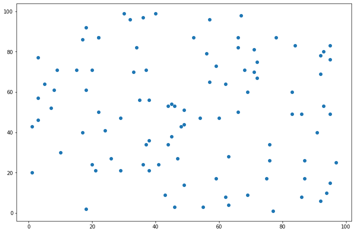

```python
plt.figure(figsize=(12,8))
plt.scatter(result,result1)
plt.show()
```

#### **Now scale the data to have a minimum of 0 and a maximum value of 1 using scikit-learn.**

```python
def NormalizeData(data):
    return (data - np.min(data)) / (np.max(data) - np.min(data))


scaled_x = NormalizeData(NewDataset)

print(NormalizeData(scaled_x))
```

```
           0         1         2         3         4
0   0.030612  0.645833  0.389474  0.618557  0.928571
1   0.642857  0.041667  0.094737  0.958763  0.397959
2   0.489796  0.854167  0.052632  0.298969  0.591837
3   0.336735  0.447917  0.726316  0.195876  0.091837
4   0.765306  0.979167  0.884211  0.000000  0.734694
..       ...       ...       ...       ...       ...
95  0.255102  0.895833  0.652632  0.618557  0.897959
96  0.704082  0.333333  0.589474  0.288660  0.153061
97  0.489796  0.979167  0.400000  0.113402  0.867347
98  0.142857  0.979167  0.926316  0.195876  0.693878
99  0.000000  0.791667  0.631579  0.896907  0.275510

[100 rows x 5 columns]
```

#### **Using your previously created DataFrame, use df.columns = […] to rename the pandas columns to be [‘f1’,‘f2’,‘f3’,‘f4’,‘label’]. Then perform a train/test split with scikitlearn.**

```python
col_labels = {0:'f1',
             1:'f2',
             2:'f3',
             3:'f4',
             4: 'label'}
NewDataset.rename(columns= col_labels, inplace=True)
NewDataset
```

|  | f1 | f2 | f3 | f4 | label |
| --- | --- | --- | --- | --- | --- |
| 0 | 4 | 63 | 40 | 60 | 92 |
| 1 | 64 | 5 | 12 | 93 | 40 |
| 2 | 49 | 83 | 8 | 29 | 59 |
| 3 | 34 | 44 | 72 | 19 | 10 |
| 4 | 76 | 95 | 87 | 0 | 73 |
| ... | ... | ... | ... | ... | ... |
| 95 | 26 | 87 | 65 | 60 | 89 |
| 96 | 70 | 33 | 59 | 28 | 16 |
| 97 | 49 | 95 | 41 | 11 | 86 |
| 98 | 15 | 95 | 91 | 19 | 69 |
| 99 | 1 | 77 | 63 | 87 | 28 |

100 rows × 5 columns

```python
print(NewDataset)
```

```
    f1  f2  f3  f4  label
0    4  63  40  60     92
1   64   5  12  93     40
2   49  83   8  29     59
3   34  44  72  19     10
4   76  95  87   0     73
..  ..  ..  ..  ..    ...
95  26  87  65  60     89
96  70  33  59  28     16
97  49  95  41  11     86
98  15  95  91  19     69
99   1  77  63  87     28

[100 rows x 5 columns]
```

```python
from sklearn.model_selection import train_test_split
X = NewDataset.drop('label', axis=1)
y = NewDataset['label']
print(X)
```

```
    f1  f2  f3  f4
0    4  63  40  60
1   64   5  12  93
2   49  83   8  29
3   34  44  72  19
4   76  95  87   0
..  ..  ..  ..  ..
95  26  87  65  60
96  70  33  59  28
97  49  95  41  11
98  15  95  91  19
99   1  77  63  87

[100 rows x 4 columns]
```

```python
X_train, X_test, y_train, y_test = train_test_split(X, y, test_size=0.33, random_state=42)
```

```python
X_train
```

|  | f1 | f2 | f3 | f4 |
| --- | --- | --- | --- | --- |
| 28 | 40 | 91 | 45 | 97 |
| 93 | 87 | 66 | 16 | 60 |
| 5 | 8 | 62 | 36 | 83 |
| 66 | 64 | 62 | 88 | 76 |
| 65 | 71 | 9 | 87 | 95 |
| ... | ... | ... | ... | ... |
| 60 | 20 | 1 | 70 | 25 |
| 71 | 27 | 47 | 13 | 70 |
| 14 | 2 | 18 | 58 | 92 |
| 92 | 79 | 56 | 65 | 93 |
| 51 | 73 | 59 | 34 | 69 |

67 rows × 4 columns

```python
y_train
```

```
28    24
93    25
5     99
66    93
65    39
      ..
60    45
71    15
14    11
92    37
51    25
Name: label, Length: 67, dtype: int32
```

```python
X_test
```

|  | f1 | f2 | f3 | f4 |
| --- | --- | --- | --- | --- |
| 83 | 69 | 92 | 20 | 15 |
| 53 | 9 | 43 | 20 | 82 |
| 70 | 40 | 17 | 32 | 83 |
| 45 | 44 | 49 | 31 | 79 |
| 44 | 34 | 37 | 57 | 35 |
| 39 | 25 | 97 | 54 | 71 |
| 22 | 71 | 20 | 27 | 75 |
| 80 | 97 | 36 | 43 | 27 |
| 10 | 24 | 36 | 63 | 19 |
| 0 | 4 | 63 | 40 | 60 |
| 18 | 71 | 68 | 23 | 35 |
| 30 | 43 | 1 | 79 | 68 |
| 73 | 82 | 34 | 5 | 46 |
| 33 | 70 | 71 | 84 | 10 |
| 90 | 53 | 46 | 14 | 27 |
| 4 | 76 | 95 | 87 | 0 |
| 76 | 51 | 49 | 74 | 82 |
| 77 | 53 | 93 | 73 | 5 |
| 12 | 8 | 86 | 26 | 87 |
| 31 | 61 | 18 | 51 | 14 |
| 55 | 81 | 71 | 25 | 94 |
| 88 | 43 | 48 | 69 | 42 |
| 26 | 24 | 20 | 64 | 52 |
| 42 | 75 | 72 | 11 | 76 |
| 69 | 14 | 49 | 97 | 25 |
| 15 | 10 | 94 | 35 | 28 |
| 40 | 80 | 93 | 64 | 63 |
| 96 | 70 | 33 | 59 | 28 |
| 9 | 17 | 75 | 79 | 97 |
| 72 | 92 | 18 | 94 | 48 |
| 11 | 30 | 10 | 60 | 20 |
| 47 | 99 | 40 | 54 | 88 |
| 85 | 54 | 45 | 38 | 15 |

```python
y_test
```

```
83    57
53    30
70    97
45    85
44    42
39    72
22     5
80    66
10    35
0     92
18    79
30    68
73    83
33    62
90    68
```

[output cut: 19 more lines]

```python
train_test_split(y, shuffle=False)
```

```
[0     92
 1     40
 2     59
 3     10
 4     73
       ..
 70    97
 71    15
 72    65
 73    83
 74    84
 Name: label, Length: 75, dtype: int32,
 75     4
 76    37
 77    37
```

[output cut: 23 more lines]